# NinePatchRect

# NinePatchRect lets you style user interface elements

This resizability makes the `NinePatchRect` ideal for any panels or UI elements you want to resize and add attractive borders to.

In this guide, you will learn how to:

- Set up a `NinePatchRect` node.
- Use a `StyleBoxTexture` resource.
- Make dialog boxes and cards.
- Create fully customizable `Button` nodes.

Contents:

Contents:

- Setting up a NinePatchRect
- NinePatchRect’s key features
- How to use a NinePatchRect in practice
  - Stylize your Buttons
  - Customize a Dialog Box
  - Create Stylized Cards
  - Create Stylized Windows
- Your questions
  - What’s the difference between StyleBoxTexture and NinePatchRect?
  - How do I make Control children fit my NinePatchRect?
- Pro Tips

## Setting up a NinePatchRect

A `NinePatchRect` needs a texture to be used to its full potential.

When creating a texture for a `NinePatchRect`, you can add a temporary grid to split the texture into nine slices: four sides, four corners, and the center. They can be any size. By using this grid, you create a system of corners and edges for the engine to read:

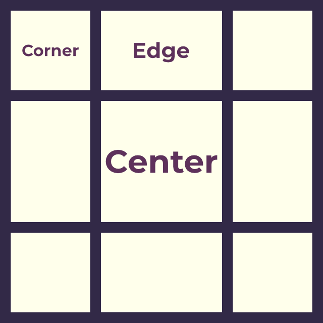

Then in the Godot editor, you can add the texture to a `NinePatchRect` and adjust the *Patch Margin* to fit the number of pixels leading up to those gridlines. This process will preserve the corners and edges of the texture while stretching the center.

## NinePatchRect’s key features

*Patch Margin* preserves a set number of pixels on the texture’s edge. Godot can then expand the inside of the texture to fit the `NinePatchRect` size.

When working with a `NinePatchRect`, the *TextureRegion* editor will open. You can use this to visually set the *Patch Margin* and the region of a texture.

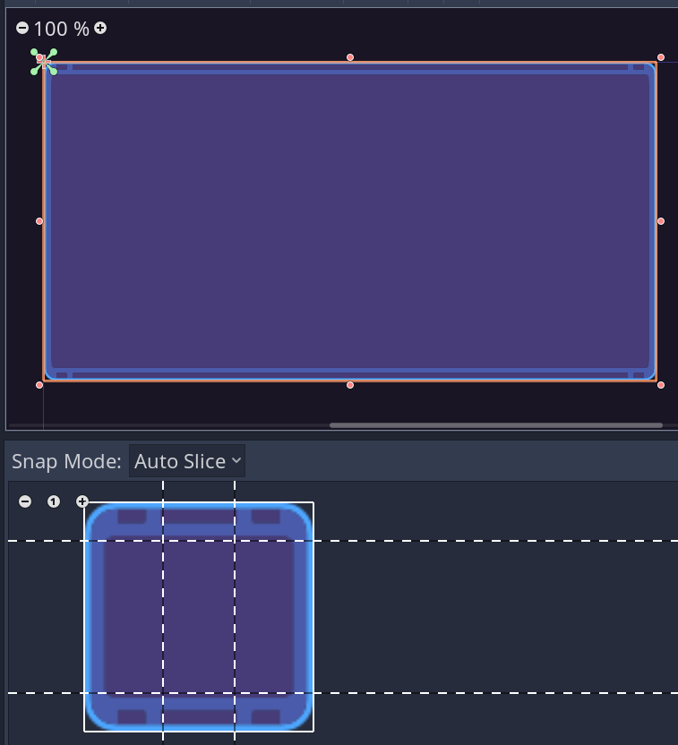

We recommend using *Auto Slice* mode as shown above to save you time and misclicks in the *TextureRegion* editor.

Using *Snap Mode -> Auto Slice* will set the texture region and patch margin automatically. You can then drag the dotted lines to adjust the patch margin more precisely.

*Axis Stretch* lets you change how the center portion of the texture fits the rest of the rectangle:

- *Stretch* scales the texture filling the space available; this can cause blurriness.
- *Tile* repeats the texture to fill the space. This setting leaves zero distortion on the pixels.
- *Tile Fit* repeats the texture until the texture can’t fit into the inner space, then it stretches the resulting tiled pixels to fit the rectangle.

*Tile Fit* allows edges to look like they match their connection to the corners, but it can introduce a small amount of stretching and pixel distortion on the borders.

By default, textures with *Tile Fit* and *Stretch* will look a bit blurry. You can make them pixelated instead by selecting the texture file, going to the *Import* dock, and setting *Flags -> Filter* to `false`.

## How to use a NinePatchRect in practice

Now that we know how to set up and adjust a `NinePatchRect` let’s look at some use cases for `NinePatchRect` and the `StyleBoxTexture` resource.

### Stylize your Buttons

The quickest way to set up a button with a `NinePatchRect` is using `StyleBoxTexture` resources, which work the same as a `NinePatchRect`’s texture and other key properties.

However, if you want to fundamentally alter the behavior of a button, it can be helpful to know how to emulate your own from the ground up.

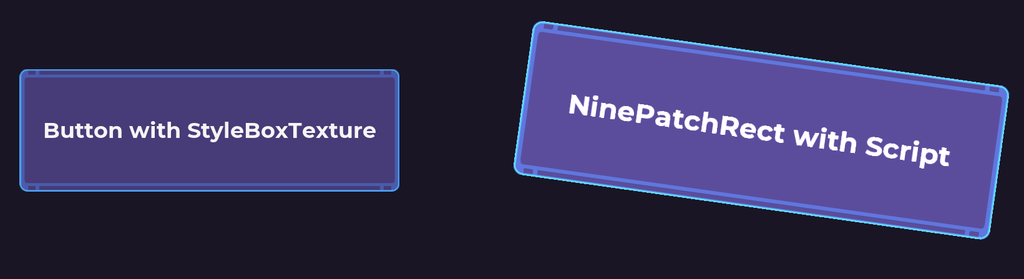

You can set up a single `NinePatchRect` and add code to make it behave like a button. Here is the code you would add to a `NinePatchRect` to make it behave like a `Button`:

```
## A NinePatchRect that responds like a button.
extends NinePatchRect

# Signals based on Button's signals. You can connect them to other scripts too.
signal pressed()
signal button_down()
signal button_up()

# AnimationPlayer to make the button grow and rotate when pressed.
onready var _animation_player: AnimationPlayer = $AnimationPlayer


func _ready() -> void:
    self.connect("mouse_entered", self, "_on_mouse_entered")
    self.connect("mouse_exited", self, "_on_mouse_exited")
```

Then, you can include a set of callback functions to make the button react to user input. We opted to change the `Button`’s *Modulation* as a quick way to adjust the color, using just one texture.

We also added an `AnimationPlayer` to make our button grow and rotate when clicked.

```
func _on_button_down() -> void:
    self.modulate = Color(0.6, 0.6, 0.6)
    emit_signal("button_down")


func _on_button_up() -> void:
    self.modulate = Color(1.3, 1.3, 1.3)
    emit_signal("button_up")


func _on_mouse_entered() -> void:
    self.modulate = Color(1.3, 1.3, 1.3)


func _on_mouse_exited() -> void:
    self.modulate = Color.white


func _on_pressed() -> void:
    _animation_player.stop()
    _animation_player.play("pressed")
    emit_signal("pressed")
```

### Customize a Dialog Box

In visual novels, players spend a lot of time looking at the dialog box. Using `NinePatchRect`, you can customize the dialog box to fit the style and tone of your game.

The real incentive to using a `NinePatchRect` is its ability to resize while tiling edges and preserving the box’s corners. It’s great for dialog boxes for your game, and it resizes to fit any display.

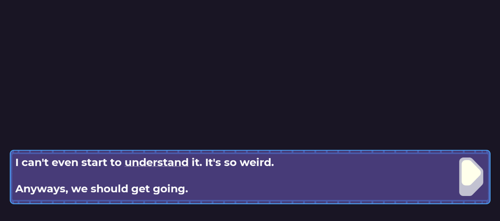

You can see how we code a dialog box by reading the PanelContainer guide.

### Create Stylized Cards

In a card game, varying up how the border of cards looks is a great way to keep the game looking interesting. You can use a `NinePatchRect` or a `PanelContainer` (with a `StyleBoxTexture`) to customize the look of the card background and borders:

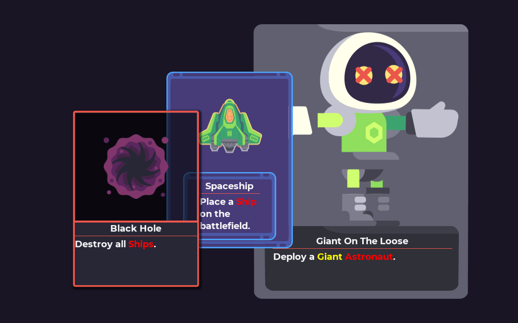

You can see how this demo’s card code works by reading the PanelContainer guide.

### Create Stylized Windows

In many management sims, you can often find movable information panels that give you information about the current game state: how much money you have, actions the player can take, and the number of staff you’ve hired.

Operating system-like windows can be seen as the UI for games like *Cities: Skylines* and *Rollercoaster Tycoon*.

[figure not shown]

*Game: Rollercoaster Tycoon 2 (2002)*

Using `PanelContainer`, we can add a `StyleBoxTexture` to use the styling of a `NinePatchRect` while adapting a `PanelContainer`’s behavior.

`PanelContainer` nodes expand the size of their children, so they’re a good base for UI containers.

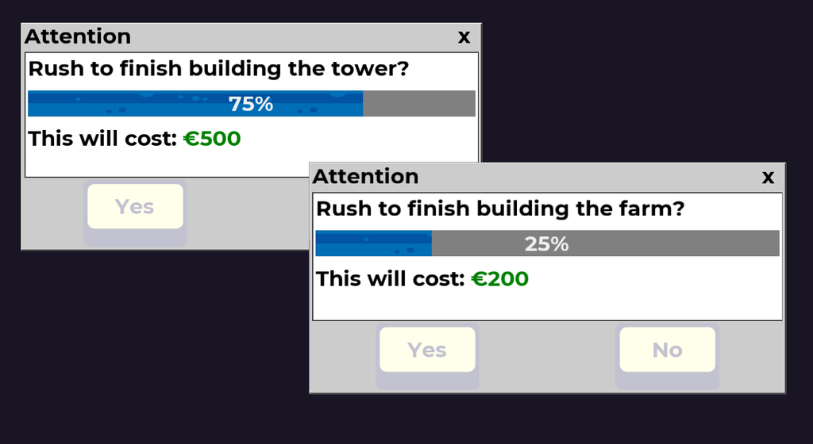

We chose not to use the `WindowDialog` node as its behavior and the layout are difficult to adjust or extend. The goal of creating this stylized window is to make it functional and highly customizable.

Here’s how we set our scene up; the draggers are the only essential component. The rest is optional to populate the window with the buttons, labels, and other nodes we want:

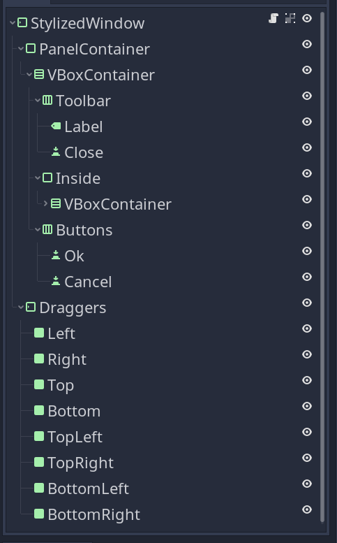

We use a `StyleBoxTexture` on each `PanelContainer`’s *Panel* property to decorate it with an older operating system look.

The outside `StyleBoxTexture`:

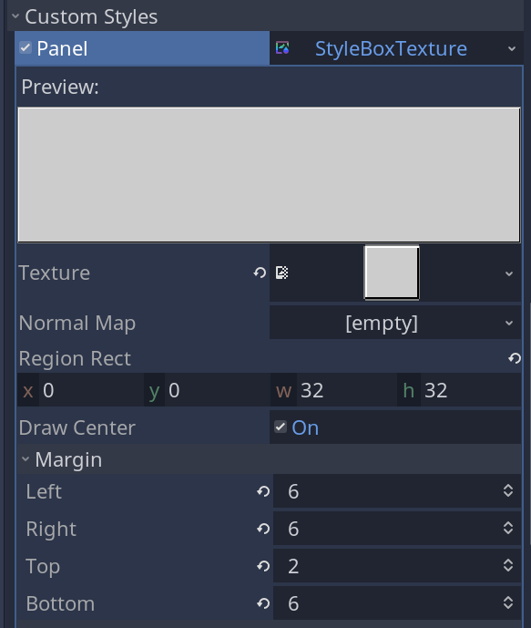

And the inside `StyleBoxTexture`:

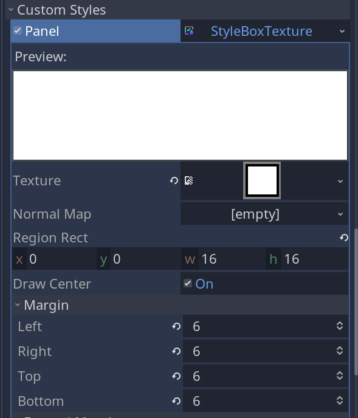

In the root node script’s `_ready()` function, we connect each dragger `Panel` to send their `gui_input` signal to a `_forwarded_gui_input()` function.

In each connection, we bind a reference to each dragger to get each node’s name later. This name lets us determine where Godot should resize the window from when dragged.

```
extends MarginContainer

export (int) var drag_size := 12

## Helps the user move the windows further with less mouse motion
const MINIMUM_DRAG = 2

## Remembers which dragger panel was last clicked.
var _dragging: String = "none"

onready var _draggers: MarginContainer = $Draggers
onready var _close: Button = $PanelContainer/VBoxContainer/Toolbar/Close
onready var _ok: Button = $PanelContainer/VBoxContainer/Buttons/Ok
onready var _cancel: Button = $PanelContainer/VBoxContainer/Buttons/Cancel


func _ready() -> void:
    for child in _draggers.get_children():
        # Increasing the dragger min size creates a larger area to grab the window.
        child.rect_min_size = Vector2(drag_size, drag_size)
        # Process their gui_input signals in a callback function, and pass the node
        # reference as a bind.
        child.connect("gui_input", self, "_forwarded_gui_input", [child])

    # For this demonstration, all buttons perform the same action.
    # You can connect them to their own callback signals to extend their abilities.
    _ok.connect("pressed", self, "queue_free")
    _close.connect("pressed", self, "queue_free")
    _cancel.connect("pressed", self, "queue_free")
```

When the player clicks, we use the built-in `_gui_input()` virtual function for the root `PanelContainer` to move the window. Clicking is one of the many inputs that trigger the function, so we can use it rather than use the `PanelContainer`’s `gui_input` signal:

```
func _gui_input(event: InputEvent):
    if event is InputEventMouseMotion and Input.is_action_pressed("click"):
        # Move the window if this node recieves any direct gui inputs.
        rect_position += event.relative
```

Now we need to make sure that any `Control` nodes that don’t need player input have their *Mouse -> Filter* set to *Ignore*.

Now everything that needs to get input from clicks needs this set to *Mouse -> Filter -> Stop* to call the `_gui_input()` function from earlier. This includes the root `PanelContainer`, dragger panels, and any buttons in the window.

Finally, we can take the `gui_input` signal from each dragger `Panel` and process it to resize our window.

We use the private variable `_dragging` to save the currently pressed dragger. This function references the dragger node, gets its name, and checks to see how this should affect the window’s size. We change the *Margin* properties of the root `PanelContainer` based on the player’s mouse movement and add a `base_drag` variable to make window adjustments more sensitive.

```
## Interprets the gui_input signals of dragger nodes, and adjusts the window margins
# depending on which dragger was grabbed.
func _forwarded_gui_input(event: InputEvent, dragger: Control) -> void:
    if event is InputEventMouseButton:
        _dragging = dragger.name if event.pressed else "none"
    if event is InputEventMouseMotion:
        var base_drag: Vector2 = event.relative.normalized() * MINIMUM_DRAG
        if "Left" in _dragging:
            margin_left += event.relative.x + base_drag.x
        elif "Right" in _dragging:
            margin_right += event.relative.x + base_drag.x
        if "Top" in _dragging:
            margin_top += event.relative.y + base_drag.y
        elif "Bottom" in _dragging:
            margin_bottom += event.relative.y + base_drag.y
```

This setup gives you a window similar to an operating system while being incredibly customizable for your game.

## Your questions

### What’s the difference between StyleBoxTexture and NinePatchRect?

`StyleBoxTexture` is a resource. `NinePatchRect` is a node.

A `StyleBoxTexture` requires a node like a `Panel` or `PanelContainer` to interpret the `StyleBox` resource and display it.

Meanwhile, `NinePatchRect` exposes all of these same properties in the *Inspector* to make adding and adjusting textures easier without dealing with `StyleBox` resources.

`NinePatchRect` is functionally identical to `Panel`. You can give a `Panel` a `StyleBoxTexture` to provide the same options as `NinePatchRect`. This guide focused on `NinePatchRect` to explore how nine-patch textures work and how you can use them to make your UI look original and engaging.

### How do I make Control children fit my NinePatchRect?

You may be trying to use `NinePatchRect` as a parent for `Control` children, but the `NinePatchRect` awkwardly shrinks behind the children when it gets too small:

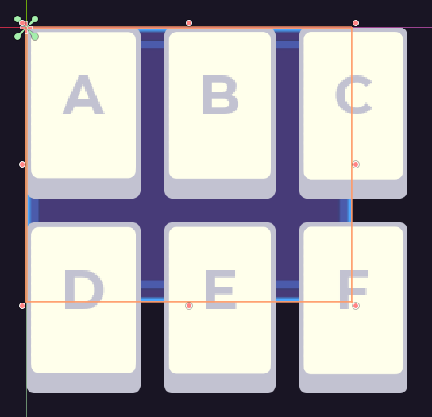

The solution is to use a `PanelContainer` as a parent instead. Here you can adjust the `Panel` property to use a `StyleBoxTexture`, making it appear just like the `NinePatchRect` node from before.

A `PanelContainer` will expand when its child contents get too big. You can read more about fitting and shrinking containers to variable text size in the PanelContainer guide.

## Pro Tips

You can save a `StyleBoxTexture` as a `.tres`, `.res`, or `.stylebox` resource file in your game. Saving resources makes it much easier to re-use settings on various `Control` nodes.

The `Theme` resource is incredibly useful for reusing style boxes across all `Control` nodes of the same type.